# INFO 640 Final Project Write-Up

Author

Andrea Thompson

Health sciences libraries often collect large amounts of operational data, but turning those records into something usable can be difficult.[^1] At Hackensack Meridian University Medical Center (HUMC), where I work, we had years of data documenting patrons’ literature search requests, including research topics, patron roles, dates, and institutional affiliations. However, the way this information was recorded changed over time. Older records were stored in inconsistent spreadsheet formats, used institution-specific abbreviations, and relied heavily on free text. Even within the same year, individual librarians used slightly different terminology.

In 2025, HUMC librarians worked with librarians from the other hospitals in the Hackensack Meridian Health (HMH) network to create a more structured system for recording library requests. In 2026, all the hospitals implemented a new, network-wide record-keeping form with standardized fields like drop-down menus for patron roles, request types, and campus affiliations. The new form will improve future data collection, but it did not solve the problem of how to analyze the existing data.

The goal of this project was to turn both legacy and current request records into usable analytical data. I wanted to better understand patrons’ information needs, identify patterns in library workload and service demand, and demonstrate the library’s value to the hospital system.

## Methods

This project uses two related analytical workflows: a historical HUMC workflow and a newer HMH network workflow.

The [HUMC workflow](https://github.com/ardthomp/640_user_analytics/tree/42d9f321c47c260d003e72adbf58559066596c8f/scripts/humc) analyzes legacy literature search request data collected at HUMC between 2013 and 2025. The legacy HUMC dataset contains 5,813 usable literature search request records and relies heavily on free-text fields, particularly for literature search topics. These records were stored across multiple spreadsheet formats and included inconsistent abbreviations, terminology, and data-entry practices across years.

The [HMH workflow](https://github.com/ardthomp/640_user_analytics/tree/42d9f321c47c260d003e72adbf58559066596c8f/scripts/hmh) analyzes harmonized network request data collected through the newer standardized request system implemented across HMH. During 2025, the hospital network began transitioning to a shared request form. During this transition period, HUMC continued using the legacy form while other hospitals used the newer network-wide form. The HMH workflow created a transitional dataset that allowed legacy HUMC records to be harmonized with newer HMH network records for longitudinal comparison.

In 2026, all hospitals adopted the shared request form and request data became consolidated into a single structured workflow. As of May 2026, the harmonized HMH network dataset includes 731 usable article/chapter request records and 235 literature search requests. The newer form also includes additional structured variables related to workload, request characteristics, and retrieval source.

I used the two workflows for different analytical goals throughout the project. I used the HUMC workflow to examine long-term historical trends and usage patterns specific to HUMC patrons. I used the HMH workflow to examine current trends, including request workload, retrieval-source patterns, and usage patterns of patrons network-wide.

All analyses were conducted in R using modular script-based workflows documented with renv. The project is organized into separate HUMC, HMH, shared-helper, and optional-modeling scripts, with intermediate datasets saved and reused across stages of the pipeline. This structure allows the analytical workflows to be rerun from raw data while keeping text processing, visualization, and modeling components modular.

The first step of the project was standardizing the legacy HUMC data across years and harmonizing it with the newer HMH network workflow, with a focus on analyzing the free-text research topic field. I used the script to remove punctuation and stop words, then applied a curated list of multi-word phrases (e.g., “rotator cuff”). I manually created and updated this list based on my observations in order to preserve meaningful concepts before tokenization. To help find new phrases over time, the script also produces updated bigram, trigram, and phrase-candidate tables during processing. Tokens were then lemmatized using [Biolemmatizer](https://biolemmatizer.sourceforge.net/), which was developed to address the unique needs of analyzing biomedical language.[^2] When Biolemmatizer could not resolve a term, I used ``` tidytext` ``-based lemmatization as a fallback. To address inconsistencies not handled by lemmatization, I created a custom mapping file to manually merge equivalent terms.

After processing, I rejoined the text data with structured metadata like requestor role and purpose. This allowed for both token-level analysis (counting all occurrences of a term) and request-level analysis (counting whether a request includes a category at least once). I used analytical methods including descriptive summaries, TF-IDF comparisons across patron groups, and chi-squared tests to examine relationships between categorical variables. The workflows use ``` ggplot2` `` to create visualizations and make the results easier to interpret.

I also created several derived variables to help analyze workflow and demand. These included time-based variables such as year, month, and weekday, which allowed for aggregation and comparison of requests over time. I also incorporated variables from the standardized form when analyzing 2026 data, such as time spent on each request, to help assess workload in a more structured way. This variable is still vague (e.g., grouped into ranges such as 1–2 hours or more than 5 hours), but it is a starting point for understanding differences in librarians’ effort across request types and user groups.

To support reproducibility, I saved all intermediate datasets—such as cleaned text, tokenized outputs, and categorized lemmas—and reused them across scripts. Saving intermediate datasets reduced processing time and made it easier to check each processing step independently. It also allowed me to add to specific components, such as refining the phrase list or updating custom merges, without needing to rerun the entire workflow from scratch–which was especially important because cleaning free-text data is repetitive.

## Results

Initial descriptive analysis of lemma frequencies showed that “PubMed” and “new publications” were among the most common terms across literature search requests network-wide (Figure 1). In response, HMH librarians are planning instructional programming on setting up search alerts in PubMed.

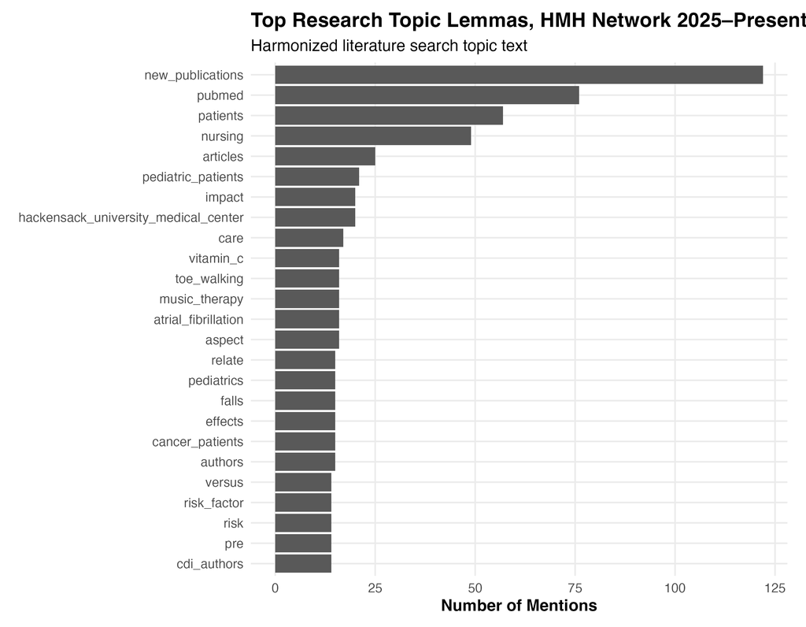

Figure 1: Top lemmas in literature search topics, HMH 2025–2026.

TF-IDF analysis revealed differences in information needs across patron groups. For example, HUMC residents were more likely to ask librarians for help finding journals for case report publication. HUMC nurses more frequently requested information related to nursing practice and assessment tools (Figure 2). The library can use these findings to tailor services—for example, HUMC librarians are adding a list of journals that publish case reports to the residents’ LibGuide.[^3]

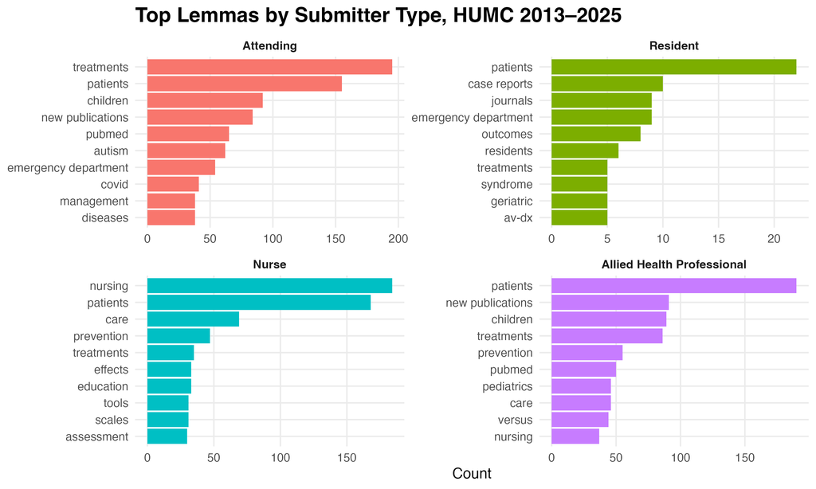

Figure 2: Top lemmas by submitter type, HUMC 2013–2025.

A chi-squared test of the relationship between submitter type and request purpose found statistically significant differences in how different requestor groups used library services at HUMC:

Table 1: Chi-squared analysis of request purpose by submitter type.

Chi-Square Test Summary

HUMC request purpose by submitter type

| Analysis | Chi-square | df | p-value | Cramer's V |
| --- | --- | --- | --- | --- |
| Request Purpose by Submitter Type | 906.71 | 50 | <0.001 | 0.184 |

For example, attendings were more likely to request literature searches for lectures and publications, while residents requested more IRB-related searches. Figure 3 shows where observed counts differed most from expected values:

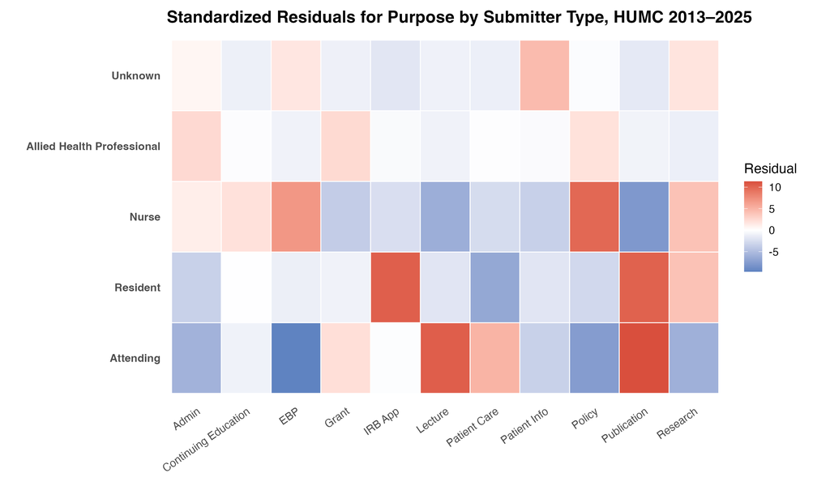

Figure 3: Standardized residuals for purpose by submitter type, HUMC 2013–2025.

These differences in information needs also affect librarian workload.[^4] Requests related to clinical decision-making, for example, often take more time. To further understand our workflow, I analyzed effort level in an [optional model](https://github.com/ardthomp/640_user_analytics/blob/42d9f321c47c260d003e72adbf58559066596c8f/scripts/optional_models/hmh_02_effort_level_by_requestor_model.R) using the newer HMH dataset, grouping requests according to reported time spent completing the search.

At a basic level, this provides a clearer picture of where librarians are spending their time (Figure 4).

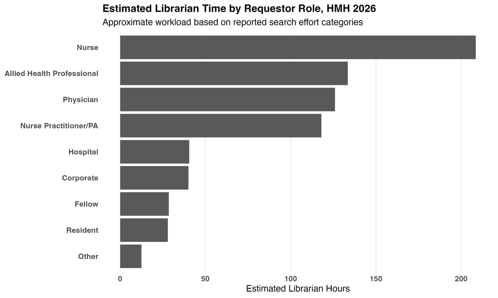

Figure 4: Estimated librarian time by requestor role, HMH 2026.

It is also helpful for us to be able to predict which request types are more likely to require higher-effort searches. The ordinal logistic regression model suggested that reported effort level varied by patron group, with some requestor categories more likely to generate medium- or high-effort searches than others.

As Figure 5 shows, fellows accounted for a disproportionately large share of estimated librarian workload relative to their share of requests, consuming approximately 1.6 times the workload expected based on request volume alone. In contrast, physician requests accounted for slightly less workload than expected relative to their proportion of requests.

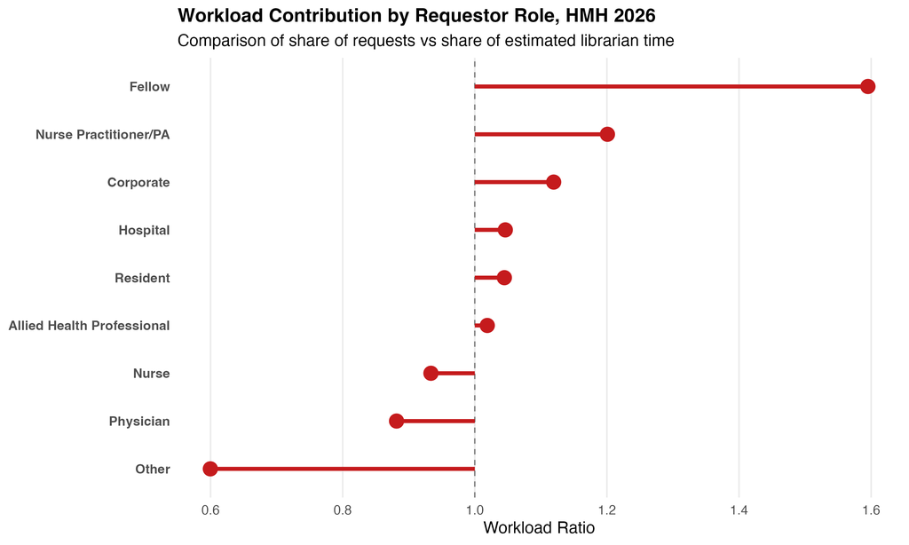

Figure 5: Workload Contribution by Requestor Role, HMH 2026

The new network-wide standardized form not only collected new information about literature search requests (like the time spent variable I just used) but also began documenting patrons’ requests for copies of articles and chapters. These records included whether library staff retrieved the materials from subscribed content or through interlibrary loan (Docline). Figure 6 shows the distribution of retrieval sources by requestor role.

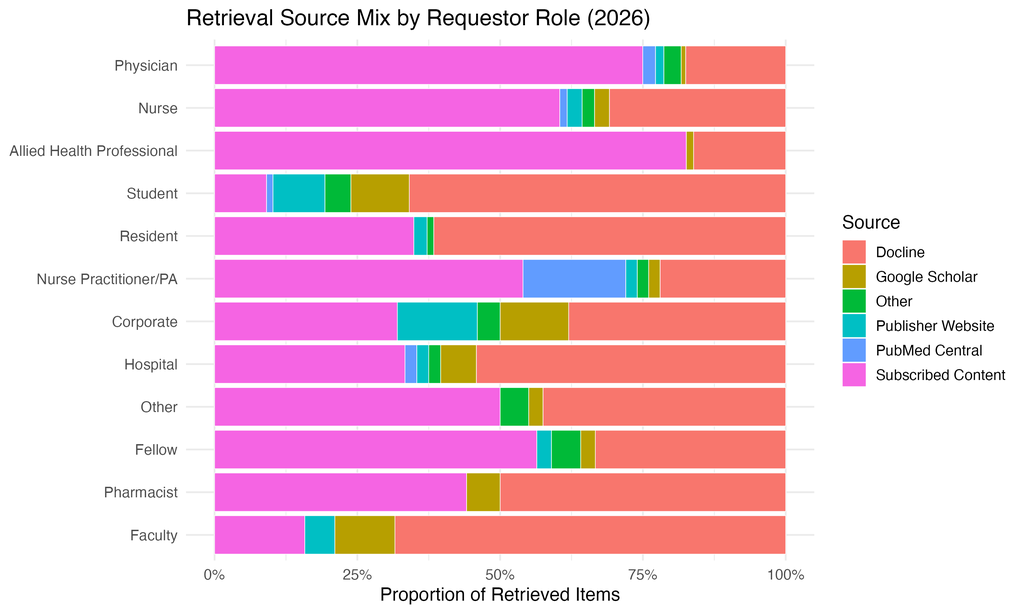

Figure 6: Retrieval source mix by requestor role, HMH 2026.

Physicians’ and nurses’ requests were largely found in subscribed resources, but library staff relied more heavily on Docline to fulfill trainees’ requests. This affects both workflow and cost, as interlibrary loan requests require more staff time and financial resources–HUMC spends hundreds of dollars on Docline each year.

Figure 7 shows that physicians and nurses account for the majority of requests. Other groups contribute smaller but still meaningful volumes.

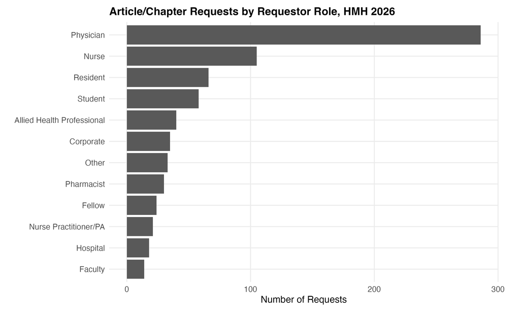

Figure 7: Article/chapter requests by requestor role, HMH 2026.

Overall, the collection appears to meet the needs of the largest user groups reasonably well, but gaps may exist for trainees. Finding these gaps could guide HMH librarians to expand collection development efforts or coordinate more closely with the affiliated medical school library on trainee requests.[^5]

I also examined demand for services using monthly request data. Figure 8 compares request volume across matched months in 2025 and 2026, showing an increase in requests. Demand for literature searches remained high in the matched 2025–2026 comparison.

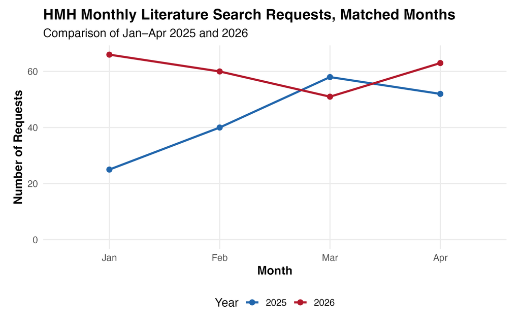

Figure 8: Monthly literature search requests, matched months, HMH 2025–2026.

I explored longitudinal patterns in request activity across the legacy HUMC dataset using another [optional model](https://github.com/ardthomp/640_user_analytics/blob/42d9f321c47c260d003e72adbf58559066596c8f/scripts/optional_models/humc_02_longitudinal_time_series.R). STL decomposition showed a stable repeating seasonal component across years (Figure 9).

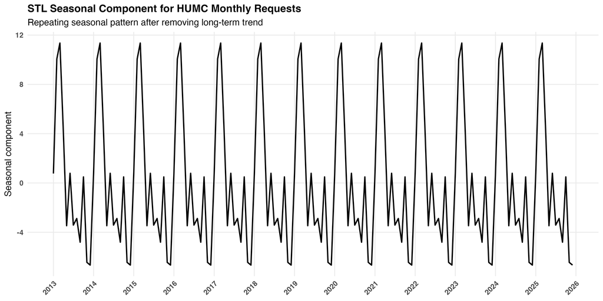

Figure 9: STL seasonal component for HUMC monthly requests.

I also conducted a Ljung-Box test for autocorrelation on the HUMC monthly request series (Table 2). The Ljung-Box test was statistically significant, indicating that monthly request volume was not temporally random and showed evidence of autocorrelation.

Table 2: Ljung-Box test for autocorrelation in HUMC monthly requests.

Ljung-Box Test for Autocorrelation

HUMC monthly request volume

| test | statistic | df | p_value |
| --- | --- | --- | --- |
| Ljung-Box | 124.15 | 12 | <0.001 |

To better understand these longitudinal patterns, I visualized monthly request volume over time (Figure 10) and trends in common research topic lemmas (Figure 11). The request volume series showed recurring fluctuations across years rather than isolated spikes.

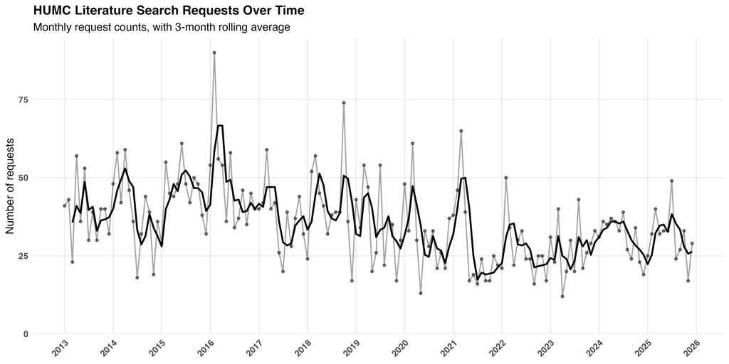

Figure 10: HUMC monthly request volume, 2013–2025.

Several common research topics appeared to rise and fall in cyclical patterns over time.

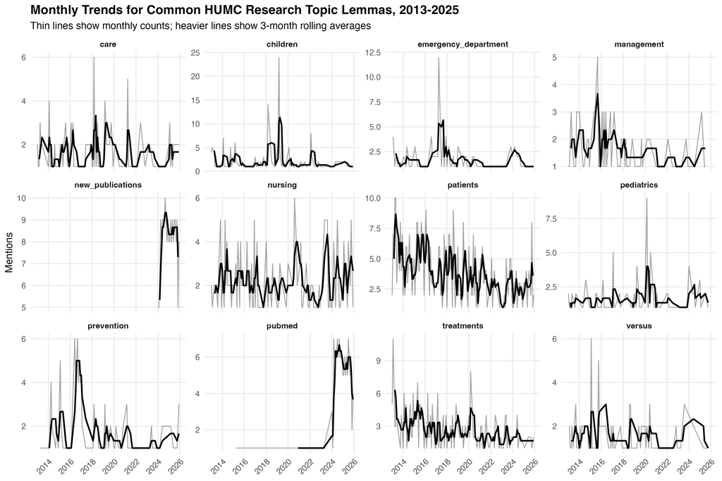

Figure 11: Monthly trends for common HUMC research topic lemmas, 2013–2025.

Connecting these cycles to specific institutional events is outside the scope of this project, but the findings indicate that hospital library demand may follow partially predictable rhythms. Understanding these patterns could help with staffing and resource planning by anticipating periods of higher demand.

## Limitations and Lessons Learned

One limitation is that the data are specific to HMH and cannot be shared outside the network due to institutional restrictions. I wrote the code to be reproducible internally, but external users cannot reproduce my findings without my data or mapping files. As a result, my findings may not generalize to other institutions—but the workflows could likely be adapted by other hospital libraries facing similar problems.

Reconciling years of inconsistent terminology and abbreviations required repeated refinement of the cleaning workflow. Over time, I found that separating the workflow into modular steps made the process much more manageable. I also learned that domain-specific tools, such as Biolemmatizer, are important when working with biomedical text, and that automated methods often need to be supplemented with manual review. However, the manually curated mapping files will require ongoing maintenance.

## Conclusion and Future Directions

Going forward, I am focused on expanding both the analytical depth and the scope of the data. The next step is to integrate data from HMH’s medical school library. This would provide a more complete picture of how trainees, many of whom have dual affiliations with the hospital system and medical school, access information resources. It could also clarify whether gaps identified in the current analysis—such as higher reliance on interlibrary loan among students and residents—are due to limitations in the collection or differences in where requests are being submitted.

Another long-term goal is to prepare this work for publication, both to document the analytical workflow and to contribute to broader discussions about assessment and service planning in health sciences libraries. My findings show that operational library data can be used to find workload patterns, anticipate periods of higher demand, and better understand how patrons use library services.

## Footnotes

[^1]: For other examples of hospital data analysis that inspired this project, see: Hannah Rutledge, “Diving into Data: Analyzing Information Requests to Understand Information Needs at a Pediatric Hospital,” *Journal of Hospital Librarianship* 18, no. 4 (2018): 293–305, https://doi.org/10.1080/15323269.2018.1509190; Laure Perrier et al., “Effects of Librarian-Provided Services in Healthcare Settings: A Systematic Review,” *Journal of the American Medical Informatics Association: JAMIA* 21, no. 6 (2014): 1118–24, https://doi.org/10.1136/amiajnl-2014-002825; Fredrik Hanell and Sara Ahlryd, “Information Work of Hospital Librarians: Making the Invisible Visible,” *Journal of Librarianship and Information Science* 55, no. 1 (2023): 70–83, https://doi.org/10.1177/09610006211063202; Danielle M. Westmark et al., “Landscape of Health Sciences Librarian-mediated Search Services,” *Health Information and Libraries Journal* 39, no. 4 (2022): 365–76, https://doi.org/10.1111/hir.12447; Laurissa B. Gann and Greg F. Pratt, “Using Library Search Service Metrics to Demonstrate Library Value and Manage Workload,” *Journal of the Medical Library Association: JMLA* 101, no. 3 (2013): 227–29, https://doi.org/10.3163/1536-5050.101.3.015; Sandra McKeown et al., “Evaluation of Hospital Staff’s Perceived Quality of Librarian-Mediated Literature Searching Services,” *Journal of the Medical Library Association: JMLA* 105, no. 2 (2017): 120–31, https://doi.org/10.5195/jmla.2017.201; Eleni Giannopoulos et al., “Identifying Gaps in Consumer Health Library Collections: A Retrospective Review,” *Journal of the Medical Library Association* 109, no. 4 (2021): 656–66, https://doi.org/10.5195/jmla.2021.895.
[^2]: Haibin Liu et al., “BioLemmatizer: A Lemmatization Tool for Morphological Processing of Biomedical Text,” *Journal of Biomedical Semantics* 3 (April 2012): 3, https://doi.org/10.1186/2041-1480-3-3.
[^3]: Rutledge, “Diving into Data.”
[^4]: Gann and Pratt, “Using Library Search Service Metrics to Demonstrate Library Value and Manage Workload”; Hanell and Ahlryd, “Information Work of Hospital Librarians.”
[^5]: Giannopoulos et al., “Identifying Gaps in Consumer Health Library Collections.”